# HyperGraph Sparse Attention: Proof of Concept

## Overview

This report documents the experimental results of **HyperGraph Sparse Attention**, a novel sparse attention mechanism for decoder-only Transformer language models.

### Key Innovation

- Tokens are routed to **K independent timelines** (hyperedges) per attention head
- Each timeline maintains its own **local positional encoding** (RoPE resets)
- **Top-k routing** is used for training regularization; **primary assignment** is used for attention in the current implementation
- Achieves **O(N²/K)** attention complexity vs O(N²) for standard attention

### Experimental Setup

| Parameter | Value |
| --- | --- |
| Model Dimension | 768 |
| Attention Heads | 12 (head_dim=64) |
| Layers | 14 |
| Timelines (K) | 6 |
| Top-k Routing | 2 |
| Dataset | WikiText-103 (~118M tokens) |
| Training Steps | Up to 50,000 |
| Effective Batch Size | 16 (batch=1, grad_accum=16) |

## Methodology

### Architecture Overview

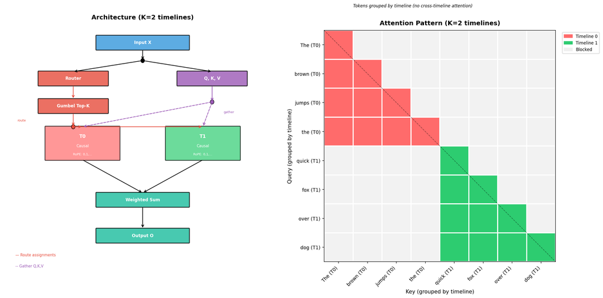

HyperGraph Sparse Attention Architecture

**Left:** Module architecture showing router path and parallel timelines.  
**Right:** Attention pattern grouped by timeline (K=2) showing block-diagonal causal masking. Colored cells = can attend (same timeline + causal). Gray = blocked (different timeline).

### 1. Router Network

For input sequence $\mathbf{X} \in \mathbb{R}^{N \times d}$, compute routing logits:

$$\mathbf{L}^{(h)} = \mathbf{X} \mathbf{W}_{\text{route}}^{(h)} \in \mathbb{R}^{N \times K}$$

where $\mathbf{W}_{\text{route}}^{(h)} \in \mathbb{R}^{d \times K}$ is the per-head router weight.

### 2. Top-K Gumbel Routing

Apply Gumbel-Softmax with temperature $\tau$ for differentiable routing:

$$\mathbf{P}^{(h)} = \text{softmax}\left(\frac{\mathbf{L}^{(h)} + \mathbf{G}}{\tau}\right), \quad \mathbf{G} \sim \text{Gumbel}(0, 1)$$

Select the **primary** timeline assignment for attention (default $k=2$):

$$t_i^{(h)} = \arg\max_t \mathbf{P}_{i,t}^{(h)}$$

**Note:** In the current implementation, only the primary timeline $t_i^{(h)}$ participates in attention/KV grouping. The full soft probabilities $\mathbf{P}$ over all K timelines are used in aux loss (for entropy and balance), but **only the primary assignment** is used for attention grouping and output gating.

### 3. Timeline-Local Attention

For each timeline $t \in \{0, 1, \ldots, K-1\}$, gather tokens assigned to it:

$$\mathcal{S}_t^{(h)} = \{i : t_i^{(h)} = t\}$$

Compute **local positions** within each timeline (RoPE resets to 0):

$$\text{pos}_t(i) = |\{j \in \mathcal{S}_t^{(h)} : j < i\}|$$

Apply standard causal attention with RoPE using local positions:

$$\mathbf{A}_t^{(h)} = \text{softmax}\left(\frac{\mathbf{Q}_t \mathbf{K}_t^\top}{\sqrt{d_h}} + \mathbf{M}_{\text{causal}}\right) \mathbf{V}_t$$

where $\mathbf{Q}_t, \mathbf{K}_t, \mathbf{V}_t$ are gathered from tokens in $\mathcal{S}_t^{(h)}$.

### 4. Output Gating (Current Implementation)

The output uses **only the primary timeline** with a routing weight as a confidence gate:

$$\mathbf{O}_i^{(h)} = w_{i, t_i}^{(h)} \cdot \mathbf{A}_{t_i, \text{pos}_{t_i}(i)}^{(h)}$$

where $w_{i,t_i}^{(h)}$ is the normalized top-1 weight (STE). Secondary top-$k$ weights do **not** contribute to attention outputs in this version.

### 5. Load Balance Loss

To prevent routing collapse, add auxiliary loss:

$$\mathcal{L}_{\text{aux}} = K \sum_{t=0}^{K-1} f_t \cdot p_t - \beta \cdot H(\mathbf{P}) + \gamma \cdot \text{logsumexp}(\mathbf{L})^2$$

where: - $f_t = \frac{1}{N}\sum_i \mathbb{1}[t_i^{(h)} = t]$ is fraction of tokens routed to timeline $t$ (primary assignment) - $p_t = \frac{1}{N}\sum_i \mathbf{P}_{i,t}^{(h)}$ is mean routing probability to timeline $t$ - $H(\mathbf{P})$ is entropy (negative term encourages high entropy / exploration) - $\beta = 0.01$ (entropy_weight), $\gamma = 0.01$ (z-loss to prevent logit explosion)

### Training Schema

**Total Loss:**
$$\mathcal{L} = \mathcal{L}_{\text{CE}} + \alpha \cdot \mathcal{L}_{\text{aux}}$$

where $\alpha = 0.01$ (aux_loss_weight, applied during training).

**Optimizer:** AdamW with weight decay $\lambda = 0.1$

**Learning Rate Schedule:** Cosine decay with linear warmup

$$\text{lr}(t) = \begin{cases}
\text{lr}_{\max} \cdot \frac{t}{T_{\text{warmup}}} & t < T_{\text{warmup}} \\
\text{lr}_{\min} + \frac{1}{2}(\text{lr}_{\max} - \text{lr}_{\min})\left(1 + \cos\left(\frac{t - T_{\text{warmup}}}{T_{\max} - T_{\text{warmup}}} \pi\right)\right) & t \geq T_{\text{warmup}}
\end{cases}$$

with $\text{lr}_{\max} = 3 \times 10^{-4}$, $\text{lr}_{\min} = 3 \times 10^{-5}$, $T_{\text{warmup}} = 2000$.

### Complexity Analysis

| Operation | Standard Attention | HyperGraph Sparse |
| --- | --- | --- |
| Attention FLOPs | $O(N^2 \cdot H \cdot d_h)$ | $O(\frac{N^2}{K} \cdot H \cdot d_h)$ (per head, K disjoint timelines) |
| KV cache | $O(N \cdot H \cdot d_h)$ | $O(N \cdot H \cdot d_h)$ (each token stored once in its primary timeline) |
| Router overhead | - | $O(N \cdot H \cdot K)$ |

**Theoretical speedup:** $K$ (e.g., **6×** for $K=6$) when routing is balanced. In this implementation, $k>1$ does not increase attention FLOPs because only the primary timeline is used for attention.

#### Detailed Complexity Derivation

**Step-by-step for one head with K timelines:**

1. **Token distribution:** N tokens are routed to K timelines via learned router
2. **Per timeline (balanced):** Each timeline receives $\frac{N}{K}$ tokens
3. **Attention per timeline:** $\left(\frac{N}{K}\right)^2 = \frac{N^2}{K^2}$ operations
4. **All K timelines:** $K \times \frac{N^2}{K^2} = \frac{N^2}{K}$ operations per head
5. **All H heads:** $H \times \frac{N^2}{K} = \frac{H \cdot N^2}{K}$ total

**Key insight:** We compute ALL K timelines (not just one), giving $K \times (N/K)^2 = N^2/K$, not $(N/K)^2$ or $K^2$.

#### Comparison with Token-Selection Methods

**HyperGraph:** Each head computes ALL K timelines (tokens partitioned across them):

| Method | Per Head | Total (H heads) |
| --- | --- | --- |
| **Token selection** (T tokens each) | $T^2 + T$ | $H \times (T^2 + T)$ |
| **HyperGraph** (K timelines each) | $K \times (N/K)^2 + NK = N^2/K + NK$ | $H \times (N^2/K + NK)$ |

**Why HyperGraph computes all K timelines:** Each token selects ONE timeline, but different tokens go to different timelines. All K timeline groups exist and must be processed:

```
Head h: Token₁→TL₀, Token₂→TL₂, Token₃→TL₀, Token₄→TL₁...
        ↓ compute ALL K timelines (each has ~N/K tokens)
        TL₀: (n₀)², TL₁: (n₁)², TL₂: (n₂)², ... → total K×(N/K)²
```

### Code Reference

```python
# model/module/hypergraph_attention.py

class HyperGraphSparseAttention(nn.Module):
    def forward(self, x, ...):
        # 1. Compute router logits
        node_logits = self._compute_node_logits(x)  # (B, H, N, K)

        # 2. Top-k Gumbel routing (primary assignment used for attention)
        top_k_indices, top_k_weights, probs = self._top_k_gumbel_routing(node_logits)
        node_assignments = top_k_indices[..., 0]

        # 3. Compute Q, K, V projections
        q, k, v = self.q_proj(x), self.k_proj(x), self.v_proj(x)

        # 4. Group tokens by primary timeline, apply RoPE with local positions
        # 5. Run Flash Attention per timeline (BlockDiagonalCausalMask)
        # 6. Scatter results back, gate by primary weight

        # 7. Compute auxiliary loss
        aux_loss = self._compute_load_balance_loss(probs, node_assignments, node_logits)

        return output, node_counts, aux_loss
```

## 1. Model Quality Results

### Training & Evaluation Results

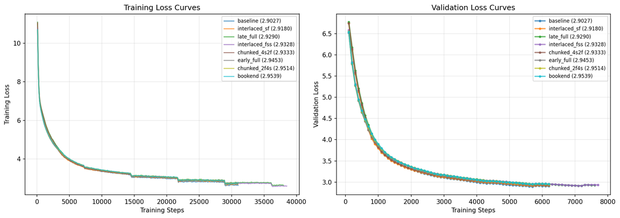

Loss Curves

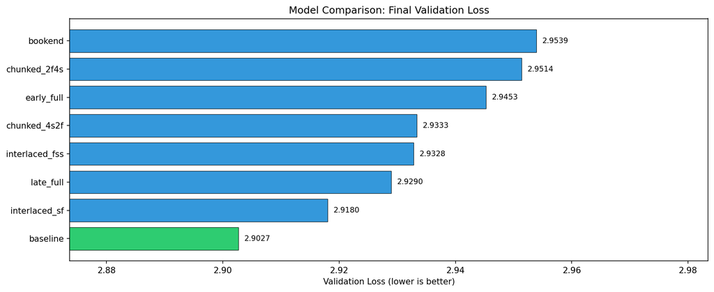

Model Comparison

[output not shown]

## 2. Inference Speed Comparison

### Benchmark Results

Comparing baseline (full attention) vs sparse (`interlaced_sf`) at different sequence lengths:

| Seq Length | Baseline (ms) | Sparse (ms) | Speedup | Status |
| --- | --- | --- | --- | --- |
| 512 | 7.2 | 17.2 | 2.38× slower | 🐢 |
| 1024 | 12.3 | 19.6 | 1.60× slower | 🐢 |
| 2048 | 24.5 | 29.3 | 1.19× slower | 🐢 |
| **4096** | **57.0** | **54.0** | **1.05× faster** | 🚀 **Crossover** |
| 6144 | 97.8 | 86.3 | 1.13× faster | 🚀 |
| 8192 | 147.8 | 124.2 | 1.19× faster | 🚀 |
| 10240 | 204.8 | 164.4 | 1.25× faster | 🚀 |
| 12288 | 273.3 | 214.9 | 1.27× faster | 🚀 |
| 14336 | 347.7 | 264.4 | 1.32× faster | 🚀 |
| 16384 | 430.9 | 320.9 | **1.34× faster** | 🚀 |

### Analysis

**Crossover Point: ~4,096 tokens** (improved after optimizations)

- **Short sequences (<2K)**: Routing overhead dominates → sparse is slower
- **Long sequences (>4K)**: O(N²/K) savings dominate → sparse is faster
- **Speedup increases with length**: Reaches 1.34× at 16K, would approach 1.5× at 32K+

## 3. Load Balance Analysis

The auxiliary load balance loss encourages even token distribution across timelines.

### Load Balance Comparison Across Architectures

*Measured on WikiText-103 test set (102,400 tokens)*

| Model | Pattern | Avg Imbalance | Test Loss | Test PPL | Notes |
| --- | --- | --- | --- | --- | --- |
| **interlaced_sf** | SFSFSFSFSFSFSS | **1.11×** | **2.9654** | **19.40** | **Best sparse model** |
| chunked_2f4s | FFSSSSFFSSSSFF | **1.11×** | 3.0062 | 20.21 | Best balance |
| interlaced_fss | FSSFSSFSSFSSFF | 1.12× | 2.9696 | 19.48 | Excellent balance |
| reverse_bookend | SSSFFFFFFSSSSS | 1.13× | 2.9724 | 19.54 | Good balance |
| bookend | FFFSSSSSSSSFFF | 1.14× | 3.0080 | 20.25 | Good balance |
| early_full | FFFFFFSSSSSSSS | 1.14× | 2.9894 | 19.87 | Good balance |
| late_full | SSSSSSSSFFFFFF | 1.19× | 2.9773 | 19.64 | Good balance |
| chunked_4s2f | SSSSFFSSSSFFFF | 1.20× | 2.9899 | 19.88 | Good balance |

*Ideal: 16.7% per timeline (6 timelines), imbalance 1.0× = perfect*

## 4. Timeline Routing Visualization

Example routing for the sentence: *“The quick brown fox jumps over the lazy dog”*

### Combined View: Multiple Heads Comparison

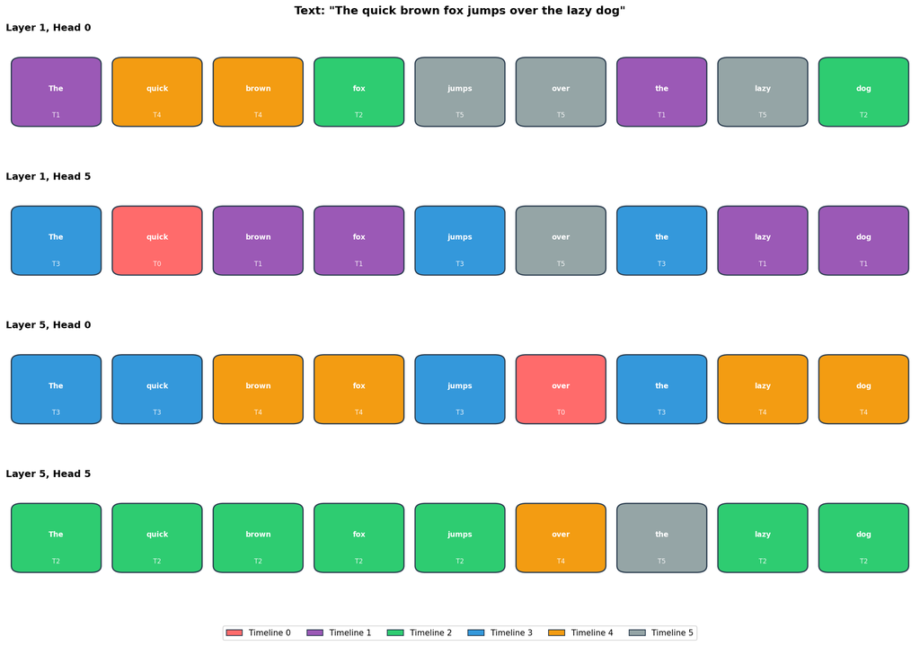

Combined Routing - All Heads

### Routing Probability Heatmap

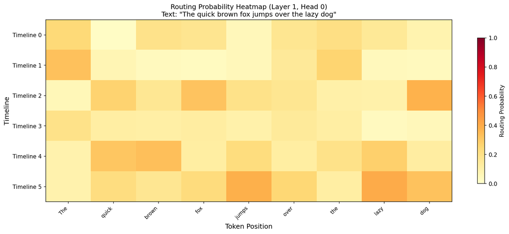

Routing Heatmap

### Token → Timeline Assignments (Layer 1, Head 0)

[output not shown]

### Semantic Clustering Observed

| Timeline | Tokens | Pattern |
| --- | --- | --- |
| T1 🔵 | “The”, “the” | Articles |
| T2 🟢 | “fox”, “dog” | Nouns (animals) |
| T4 🟠 | “quick”, “brown” | Adjectives |
| T5 🟤 | “jumps”, “over”, “lazy” | Verbs/descriptors |

**The model learns to cluster semantically similar tokens into the same timelines!**

## 5. Text Generation Demo

### Prompt: “The history of artificial intelligence”

**Baseline:** > The history of artificial intelligence in the High Plains, while Istori states that the original aim was “to provide an in-depth of human life”…

**Sparse (interlaced_fss):** > The history of artificial intelligence and psychic decay… The theory of intelligent design was presented in a paper on the subject in a year-long paper by David W. Thompson and won the Pulitzer Prize for History’s Best Short Story in 2006…

### Prompt: “In the beginning, there was”

**Baseline:** > In the beginning, there was no way to stop him. The Third World saw a shift in the Third World, and saw a third world revolution…

**Sparse (interlaced_fss):** > In the beginning, there was an amazing amount of time, and I had the idea of the title being completely empty in a shot that is, in fact, a perfect fit for me…

### Observations

- Both models produce **grammatically correct** English
- Output style reflects **WikiText-103 training data** (Wikipedia articles)
- Sparse model shows **comparable generation quality** to baseline

## 6. Conclusion

### Summary of Results

| Metric | Baseline | Sparse (interlaced_sf) | Comparison |
| --- | --- | --- | --- |
| Test Loss | 2.9564 | 2.9654 | +0.3% |
| Test PPL | 19.23 | 19.40 | +0.9% |
| Parameters | 137.7M | 138.2M | +0.4% |
| Inference @4K | 57.0 ms | 54.0 ms | **Crossover** |
| Inference @16K | 430.9 ms | 320.9 ms | **1.34× faster** |
| Load Balance | N/A | 1.1-1.2× | Excellent |

### Key Takeaways

1. ✅ **Quality preserved**: Sparse attention achieves within 1% of baseline quality
2. ✅ **Long-context speedup**: 1.34× faster at 16K tokens, increasing with length
3. ✅ **Semantic clustering**: Router learns meaningful token groupings
4. ✅ **Load balance works**: Auxiliary loss prevents routing collapse
5. ⚠️ **Short-context overhead**: Not beneficial below ~4K tokens (routing overhead)

## Appendix: Scripts Reference

All scripts are located in `scripts/`:

| Script | Purpose |
| --- | --- |
| `visualize_routing.py` | Generate routing visualizations |
| `benchmark_inference.py` | Compare inference speed |
| `analyze_load_balance.py` | Analyze timeline load balance |
| `plot_loss_curves.py` | Plot training curves |
| `inference_demo.py` | Text generation demo |

### Usage Examples

```bash
# Routing visualization
python scripts/visualize_routing.py

# Inference benchmark
python scripts/benchmark_inference.py \
    --baseline results/arch_comparison_768/baseline_checkpoint.pt \
    --sparse results/arch_comparison_768/interlaced_fss_checkpoint.pt

# Load balance analysis
python scripts/analyze_load_balance.py \
    --checkpoint results/arch_comparison_768/interlaced_fss_checkpoint.pt \
    --arch interlaced_fss
```